# Health Data

Author

Belen Zapata-Diomedi, Steve Pemberton

Published

November 15, 2025

# 1 Introduction

This document explains and produces estimates for the inputs for the health model for MIAMA. The model initially has four stages where individuals are in a healthy state, might become diseased of one or more diseases, and die from any causes (all cause mortality). All cause mortality is also dependent on diseases status, meaning that if a person has a given disease (i.e. diabetes, dementia, parkinson, cancers, copd) their probability of dying is higher. Diabetes is a risk factor for cardiovascular diseases (ischemic heart disease and stroke) and included in the model. The model does not include trend of diseases but assumes that current rates by age, sex and area will be observed in the future.

The purpose of this document is to produce health inputs for all-cause mortality and diseases’ incidence and prevalence. Prevalence is used to assign initial state as diseased.

# 2 All-Cause Mortality

## 2.1 Data Sources

1. Mortality by LSOA by age and sex for year 2018 from ONS.

   https://www.ons.gov.uk/peoplepopulationandcommunity/birthsdeathsandmarriages/deaths/adhocs/1028deathregistrationsbysexfiveyearagegroupandlowerlayersuperoutputareaslsoa2011censusboundariesenglandandwales2001to2021
2. Population Data by LSOA by age and sex for 2018 mid year, and 2023 mid year [NOT CURRENTLY USED] (downloaded 12-Nov-25), from ONS.

   https://www.ons.gov.uk/peoplepopulationandcommunity/populationandmigration/populationestimates/datasets/lowersuperoutputareamidyearpopulationestimates
3. Geographical Hierarchy (as of 2011) and table of correspondences to regions

   https://geoportal.statistics.gov.uk/datasets/ons::lsoa-2011-to-travel-to-work-area-december-2011-exact-fit-lookup-in-the-uk/about

   https://geoportal.statistics.gov.uk/datasets/ons::lsoa-2011-to-lsoa-2021-to-local-authority-district-2022-best-fit-lookup-for-ew-v2/about
4. Life tables England (2017-2019)

   https://www.ons.gov.uk/peoplepopulationandcommunity/birthsdeathsandmarriages/lifeexpectancies/datasets/nationallifetablesenglandreferencetables/current
5. Level of multiple deprivation

   https://opendatacommunities.org/resource?uri=http%3A%2F%2Fopendatacommunities.org%2Fdata%2Fsocietal-wellbeing%2Fimd2019%2Findices
6. European standard population

   https://publichealthscotland.scot/services/national-data-catalogue/national-datasets/search-the-datasets/european-standard-population/
7. Age-standardised mortality rates from ONS for 2018, downloaded 8-Nov-25

   https://www.nomisweb.co.uk/datasets/mortsa

   Details selected for download:
   - Geography: ’local authorities: district / unitary (as of April 2023)
   - Date: 2018
   - Age: All
   - Rates: Age-standardised mortality rate
   - Sex: All
   - Underlying Cause > Full ICD_10 Classification: Total

## 2.2 Mortality rates by year of age and sex for England

The mortality rate `mx` is defined as “the number of deaths at age x last birthday in the three year period (2017-2019) divided by the average population at that age over the same period. This is the starting data to further expand by LSOAs based on the ratio of the age-standardised mortality rates by sex for each LSOA relative to England as a whole. ASDR are not publicly available at LSOA, therefore, we calculated them.

## 2.3 Population weights for age groups and sex for England

To derive age-standardized rates for each LSOA by sex and then derive ratios of mortality rate for LSOAs by sex, we need population weights for our reference population of England. We constructed these weights using population data for England. We also, further down the document, construct ratios using European standard population for validation purposes of data by LAD (for which there are publicly available ASDR by LAD and sex).

## 2.4 Relative Risk

A relative mortality rate is produced for each area (lsoa), defined as the age-standardised mortality rate by sex for each lsoa relative to the average mortality in England by sex.

The age-standardized mortality rate (ASMR) (direct standardization) by sex and lsoa is calculated by first finding the age-specific (mortality) rates for each age group (5 years) by dividing the number of deaths by the respective population by sex, then multiplying the result by 1000, then the sum of the product of each of the age-specific rates by the proportion of the population belonging to the particular age group (standard population weight) by area and sex. For England as a whole, the average mortality is defined as a weighted average of the area-specific rates, weighted by the population of each area.

For future reference ( https://pmc.ncbi.nlm.nih.gov/articles/PMC9575652) we might want to improve the calculation of ASDR.

We calculated ASDRs for lsoas, msoas and lads. While we want the relative risks for each lsoa compared to England as a whole, some lsoa have small deaths numbers, in those cases we replaced by msoas or lads if msoas still had small numbers. We applied a rule that if less than 10 deaths in an age group in an lsoa, then a msoa ASDRs should be used, and if more than 10 deaths but less than 20 in an MSOA, then use the LAD ASDRs.

### 2.4.1 LSOAs. MSOAs and LADs ASDRs by sex

## 2.5 Deprivation data

## 2.6 Apply to life tables, calibrate and smooth

```
# A tibble: 1 × 5
  area                observed assigned_cal  diff pct_diff
  <chr>                  <dbl>        <dbl> <dbl>    <dbl>
1 England (all LAD22)   514330      515579. 1249.    0.243
```

```
# A tibble: 1 × 5
  area                observed assigned    diff pct_diff
  <chr>                  <dbl>    <dbl>   <dbl>    <dbl>
1 England (all LAD22)   514330  456714. -57616.    -11.2
```

## 2.7 Death rates grouped

We summarise death rates in two ways: (1) grouping by IMD decile (weighted mean of the rates for all LSOAs in each IMD decile), and (2) finding the middle rate of the deciles for all LSOAs combined. In each case, these are based on the calibrated and smoothed rates as calculated above.

## 2.8 Graphs for checking results

### 2.8.1 Death rates by LSOA

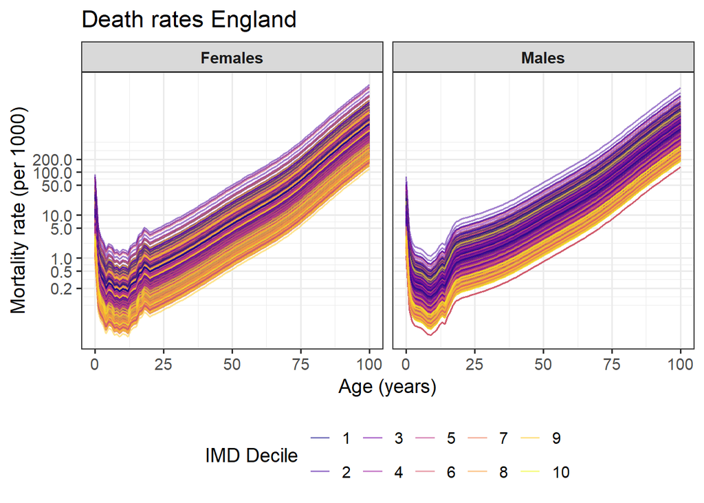

### 2.8.2 Death rates by IMD deciles

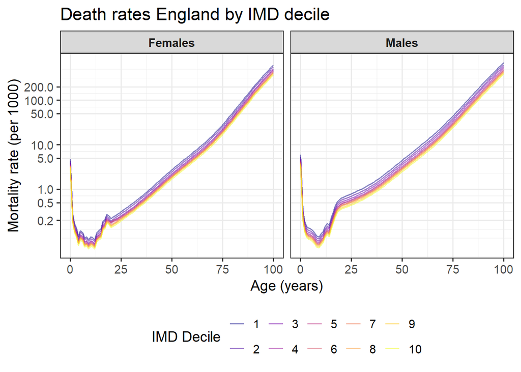

### 2.8.3 Death rates by decile midrates

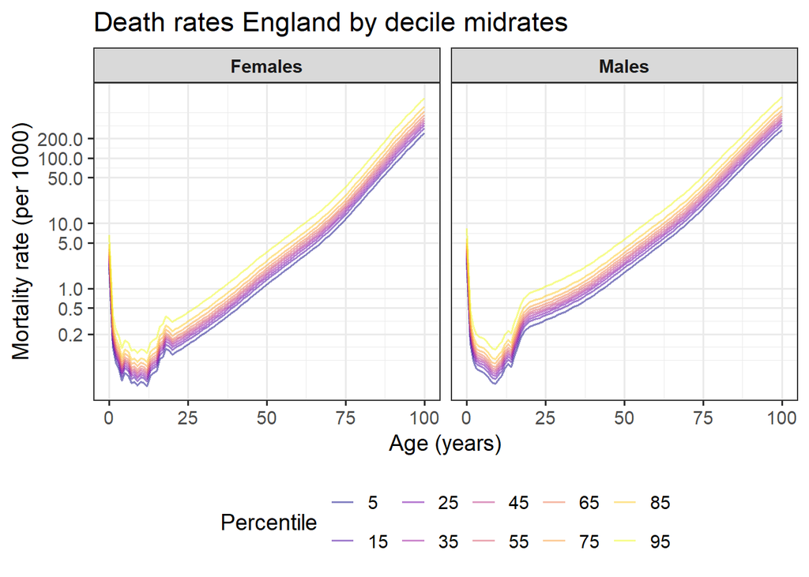

## 2.9 Comparison with publicly available estimates by LADs and sex

Comparison of age standardised rates with ONS data by LAD and our calculations but using weight from the European standard population. We use European standard population to compare because ASDR per LAD from ONS use this weights in their calculations.

stdr_rate ons is publised, stdr_rate_eng is calculated by us using England population weights and stdr_rate_eu is our estimates using European standard population weights. Our estimates using European standard rates compare with published ONS rates.

```
# A tibble: 568 × 5
   gender lad_name             stdrate_ons stdrate_eng stdrate_eu
   <chr>  <chr>                      <dbl>       <dbl>      <dbl>
 1 Males  Hartlepool                  12.5       11.0        13.1
 2 Males  Middlesbrough               14.6       13.7        16.3
 3 Males  Redcar and Cleveland        12.3        9.90       11.9
 4 Males  Stockton-on-Tees            12.7       10.3        12.3
 5 Males  Darlington                  11.4        9.14       11.0
 6 Males  County Durham               12.7        9.96       12.0
 7 Males  Northumberland              11.6        9.15       11.0
 8 Males  Newcastle upon Tyne         12.8       10.4        12.4
 9 Males  North Tyneside              12.1       10.2        12.2
10 Males  South Tyneside              14.6       11.7        14.1
# ℹ 558 more rows
```

# 3 Disease Incidence and Prevalence

For a list of diseases related to the modeled health risk factors including physical activity, air pollution (PM25 and NO2), noise and greenspace, we need incidence rates by age, sex and also by LAD (available from GBD). We also need prevalence to assign initial health state in the model. The main data transformations were to:

1) interpolate from 5 year age groups to 1.

2) Adjust colon and rectum cancers to only reflect on colon cancer proportion.

3) Adjust Tracheal, bronchus, and lung cancer to only reflect on lung cancer.

4) Replace rates for LADs with small numbers of incidence and prevalence with higher level data for Greater Manchester.

## 3.1 Data sources

Diseases for all of England by 5-year age bands and sex for year 2023 from GBD, downloaded 12-Oct-25.

https://vizhub.healthdata.org/gbd-results/

```
Parameters:
- GBD Estimate - Cause of death or injury
- Measure: Incidence, Prevalence
- Metric: Number, Percent, Rate
- Cause: Stroke, Ischemic heart disease, Breast cancer, Uterine cancer, Tracheal, bronchus and lung cancer, Colon and rectum cancer, Esophageal cancer, Liver cancer, Stomach cancer, Chronic myeloid leukemia, Multiple myeloma, Larynx cancer, Lip and oral cavity cancer, Nasopharynx cancer, Other phary…
- Location: England
- Age: <5, 5-9, 10-14, … 90-94, 95+ [total 20]
- Sex: Female, Male
- Year: 2023
- Names (not IDs)
```

For colon cancer, in the absence of estimated for England, we adjusted incidence and prevalence based on estimates from the American Cancer Society (https://www.cancer.org/cancer/types/colon-rectal-cancer/about/key-statistics.html, accessed 12-Oct-25). Estimates for 2025 are 107,320 new cases of colon cancer and 46,950 estimates of rectal cancer. We assume that 70% of Colon and rectum cancer is colon cancer for both incidence and prevalence

For lung cancer, we compare total Tracheal, bronchus, and lung cancer incidence for 2021 from GBD data (https://vizhub.healthdata.org/gbd-results/, accessed 12-Oct-25) with England lung cancer incidence statistics for 2021 (https://digital.nhs.uk/data-and-information/publications/statistical/cancer-registration-statistics/england-2021---summary-counts-only/cancer-incidence, accessed 12-Oct-25). GBD estimates 37,682 incident cases of Tracheal, bronchus, and lung cancer and estimates from England indicate 20,312. We assume that 54% of Tracheal, bronchus, and lung cancer is lung cancer for both incidence and prevalence.

## 3.2 Interpolation

Plots comparing gbd incidence rates before and after interpolation are saved in the `images/inc_gbd_age_sex` folder.

## 3.3 Apply relative risks, add deprivation data

We apply the relative risks for each LSOA to the disease data. We assume that the relative risks calculated above for mortality apply also to disease. *[This assumption may be reconsidered further.]*

### 3.3.1 Incidence

#### 3.3.1.1 Incidence rates by LSOA

#### 3.3.1.2 Incidence rates grouped

We summarise incidence rates in two ways: (1) grouping by IMD decile (weighted mean of the rates for all LSOAs in each IMD decile), and (2) finding the middle rate of the deciles for all LSOAs combined.

#### 3.3.1.3 Graphs for checking results

##### 3.3.1.3.1 Incidence rates by LSOA

Plots of disease incidence rates by LSOA are saved in the `images/inc_lsoa` folder.

##### 3.3.1.3.2 Incidence rates by IMD deciles

Plots of disease incidence rates by IMD deciles are saved in the `images/inc_imd_decile` folder.

##### 3.3.1.3.3 Incidence rates by decile midrates

Plots of disease incidence rates by decile midrates are saved in the `images/inc_decile_midrate` folder.

### 3.3.2 Prevalence

#### 3.3.2.1 Prevalence rates by LSOA

#### 3.3.2.2 Prevalence rates grouped

We summarise prevalence rates in two ways: (1) grouping by IMD decile (weighted mean of the rates for all LSOAs in each IMD decile), and (2) finding the middle rate of the deciles for all LSOAs combined.

#### 3.3.2.3 Graphs for checking results

##### 3.3.2.3.1 Prevalence rates by LSOA

Plots of disease prevalence rates by LSOA are saved in the `images/prev_lsoa` folder.

##### 3.3.2.3.2 Prevalence rates by IMD deciles

Plots of disease prevalence rates by IMD deciles are saved in the `images/prev_imd_decile` folder.

##### 3.3.2.3.3 Prevalence rates by decile midrates

Plots of disease prevalence rates by decile midrates are saved in the `images/prev_decile_midrate` folder.

# 4 Combining All-cause Mortality and Disease Incidence Data (by IMD deciles)

Saves the files required by the health model: `health_transitions_prevalence.csv` and `health_transitions_raw.csv`.

Note that the output rates are raw rates. *We may later adjust them for levels of physical activity in the population.*